# Project Report for "How will your professor grade you for a course? Check the past statistics!" (By Li Ju)

## Section 1: Dataset Description

The dataset is called "uiuc-gpa-dataset.csv". Its source is

"https://github.com/wadefagen/datasets/blob/master/gpa/uiuc-gpa-dataset.csv". The dataset contains 15784 rows and 21

columns. Generally the dataset showed the number of each letter grade in each course in UIUC, from 2010 summer

semester to 2020 spring semester. Each row in the dataset shows the semester when the course is taught, the course

subject, number, title, the numbers of each letter grade, the primary instructor, etc.

Here are the detailed descriptions for 21 variables in the dataset:

- `Year`: which year the course was taught in
- `Term`: which term the course was taught in
- `Year-Term`: which year and which term the course was taught in
- `Subject`: which subject the course belonged to
- `Number`: what course number the course had
- `Course Title`: the name of the course
- `A+`: how many students gained 'A+' in the course
- `A`: how many students gained 'A' in the course
- `A-`: how many students gained 'A-' in the course
- `B+`: how many students gained 'B+' in the course
- `B`: how many students gained 'B' in the course
- `B-`: how many students gained 'B-' in the course
- `C+`: how many students gained 'C+' in the course
- `C`: how many students gained 'C' in the course
- `C-`: how many students gained 'C-' in the course
- `D+`: how many students gained 'D+' in the course
- `D`: how many students gained 'D' in the course
- `D-`: how many students gained 'D-' in the course
- `F`: how many students gained 'F' in the course
- `W`: how many students withdrew the course
- `Primary Instructor`: the instructor of the course

## Section 2: Question of Interest

The goal of my web application is to help students check how professors grade students for a certain course they are

interested in. For example, Henry is considering to register for STAT100 for next semester but he is uncertain that he

should choose which section by which professor. Henry cares his GPA and he hopes STAT100's professor does not have

very harsh grading metric. That is the time Henry should try my web application. If he inputs 'STAT' and '100' in two

input boxex, he will see a vivid visualization about the distribution of letter grades ,"A", "B", "C", "D" and "F",

graded by all professors taught STAT100 in past 10 years. If he clicks on each bar in the graph, he can see how many

students graded by a certain professor as well as the average GPA the professor gave to students.

## Section 3: Test of my Web Application

### step 1: check the input options

Firstly, I would like to check whether the input options of my second input box modify according to the input option

of my first input box.

If I choose `STAT` subject, I will have course number options like `100`, `107`, `200`, `212`, `385`, `400` and so on,

which are course numbers for STAT courses.

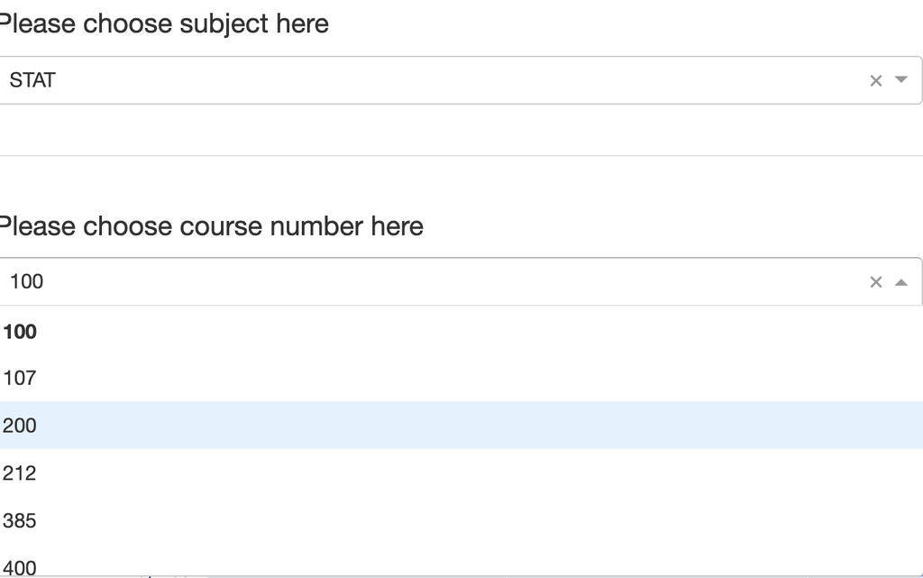

If I choose `RHET` subject, I will have course number options like `233`, `105`, `243`, which are course numbers for RHET courses.

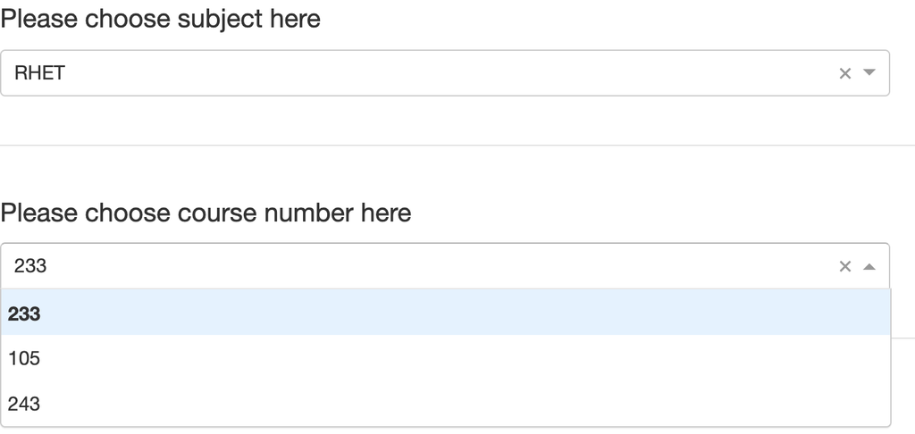

### step 2: Check whether the graph changes according to the subject and course number change

Secondly, I will check whether the graph changes according to the subject and course number change.

If I select `STAT 100` and `STAT385`, we can see 2 different visualizations respectively.

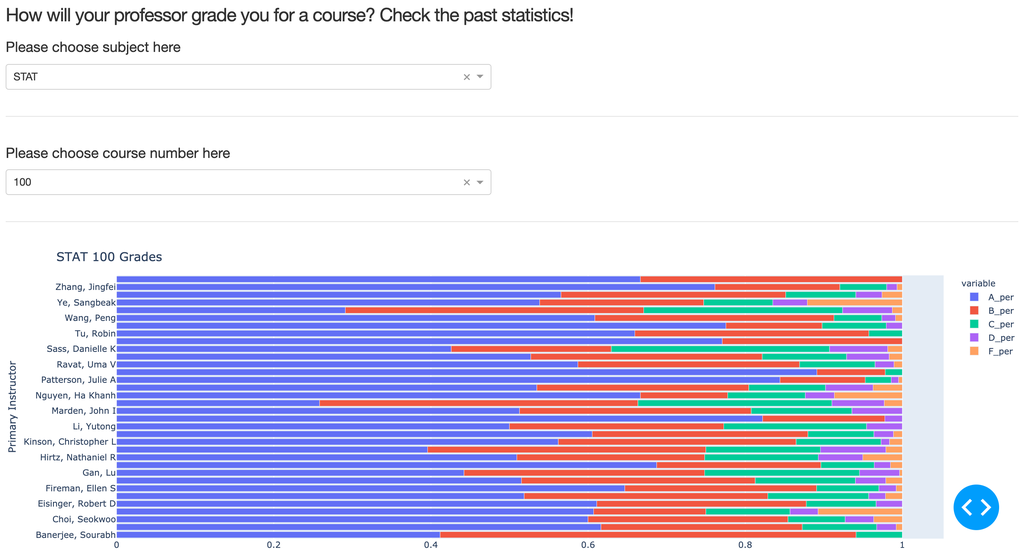

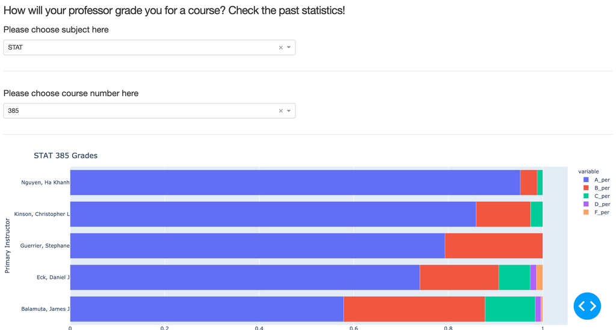

If I select a different subject, for example, `ECON`, and I checked `ECON 102` and `ECON 437`.

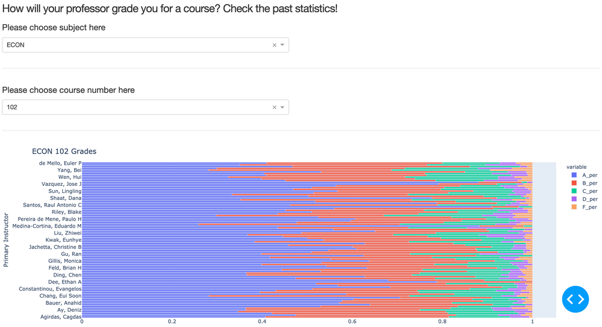

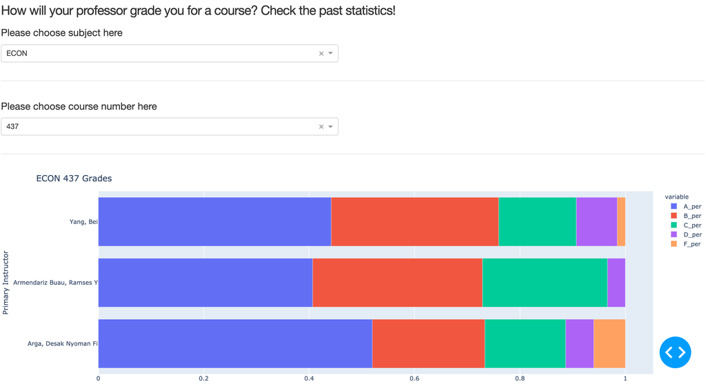

### step 3: look closely on the graphs

If I click the sub-bar on each bar on my graph, I can see some detailed statistics. For example, this is a part of the

generated graph if I input `EALC` and `250`. The first bar in the graph is how professor `Wilson, Roderick I` grades

his students over the past semesters. We can see that **43.83%** of students in his class got letter grade of 'B'; the

average GPA of his class is **2.85** ; Professor Wilson totally taught **146** students for EALC250.

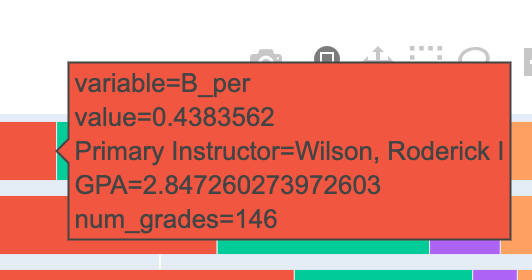

## Section 4 Conclution & Discussion

I believe I did well in data prepocessing and transformation. For example, I use `groupby` mechanics to calculate some

statistics of each course taught by a certain professor. Also, I obtained the specific GPA data after some data

transformation. I also labeled GPA and number of students of each course taught by a certain professor in the data

visualization.

If someone will continue working on my project, I believe my application could be more functional. For example, a

professor may teach STAT 100 for several semesters, and a student want to check the grading for each semester

separately. A slider should be added for choosing a certain time period. Also, some line charts could be created to

show how the GPA graded by a certain professor changed over semesters.